# Project Estimator Continued (Using R)

Aaron Johnson

April 24, 2019

```r
library(ggplot2)
library(dplyr)
library(corrplot)
```

## Introduction

In this notebook I will continue to explore the data I’ve collected from my business in order to create a project length estimator.

In the past, the best model predictions came from using a linear SVC algorithm. However, I’d like to try using Linear Regression since I have more data to work with. Also, with Linear Regression I’ll have the added benefit of the model being more interpretable.

In previous iterations of this exploration, I created the variable **hour_page** by taking the total number of hours to complete the project (hours) divided by the total number of pages in the final project (number_pages). I then used this variable to create a difficulty rating for each project. Since the complexity of a project can vary, I needed a way to guess at a project’s difficulty at the beginning. If you’re interested in more detail about how and why I created the difficulty variable, or for more background in general, check my previous post [here](https://aaronbjohnson.github.io/first-post.html).

The difficulty variable was created by dividing the **hour_page** variable’s range by 5 to get 5 difficulty levels. However, I think there is a better way to divide this difficulty column, other than just an even division.

Let’s take a look at the data.

```r
df <- read.csv('./data/engineered_data.csv')
head(df)
```

```
##   case_type number_pages X3d_modeling hours hour_page difficulty
## 1    design            6           no  2.75 0.4583333          1
## 2   utility           16           no 11.00 0.6875000          1
## 3   utility            5           no  3.75 0.7500000          1
## 4   utility            9           no  5.75 0.6388889          1
## 5   utility            4           no  7.25 1.8125000          2
## 6   utility           23           no 12.25 0.5326087          1
```

```r
str(df)
```

```
## 'data.frame':    155 obs. of  6 variables:
##  $ case_type   : Factor w/ 2 levels "design","utility": 1 2 2 2 2 2 2 2 2 2 ...
##  $ number_pages: int  6 16 5 9 4 23 10 5 9 25 ...
##  $ X3d_modeling: Factor w/ 2 levels "no","yes": 1 1 1 1 1 1 1 1 1 1 ...
##  $ hours       : num  2.75 11 3.75 5.75 7.25 ...
##  $ hour_page   : num  0.458 0.688 0.75 0.639 1.812 ...
##  $ difficulty  : int  1 1 1 1 2 1 1 1 1 1 ...
```

Let’s convert the **difficulty** variable to a factor.

```r
df$difficulty <- as.factor(df$difficulty)
```

```r
summary(df)
```

```
##    case_type    number_pages    X3d_modeling     hours
##  design : 53   Min.   : 1.000   no :124      Min.   : 0.750
##  utility:102   1st Qu.: 5.000   yes: 31      1st Qu.: 3.250
##                Median : 6.000                Median : 5.000
##                Mean   : 8.039                Mean   : 5.926
##                3rd Qu.: 9.000                3rd Qu.: 7.250
##                Max.   :48.000                Max.   :26.700
##    hour_page      difficulty
##  Min.   :0.2000   1:128
##  1st Qu.:0.5174   2: 24
##  Median :0.7500   3:  1
##  Mean   :0.8753   4:  1
##  3rd Qu.:1.0000   5:  1
##  Max.   :5.3000
```

Here is where we can start to see the problem with how I’ve originally created the **difficulty** column. About **83 percent** of the projects have a difficulty level of 1. We can also see that I’m not really making use of the 3, 4, and 5 difficulty levels, as they each only have 1 project assigned to them.

Let’s move on to investigating more by creating some visuals.

## EDA

First let’s look at the target variable **hours** vs **number_pages**, colored by case type.

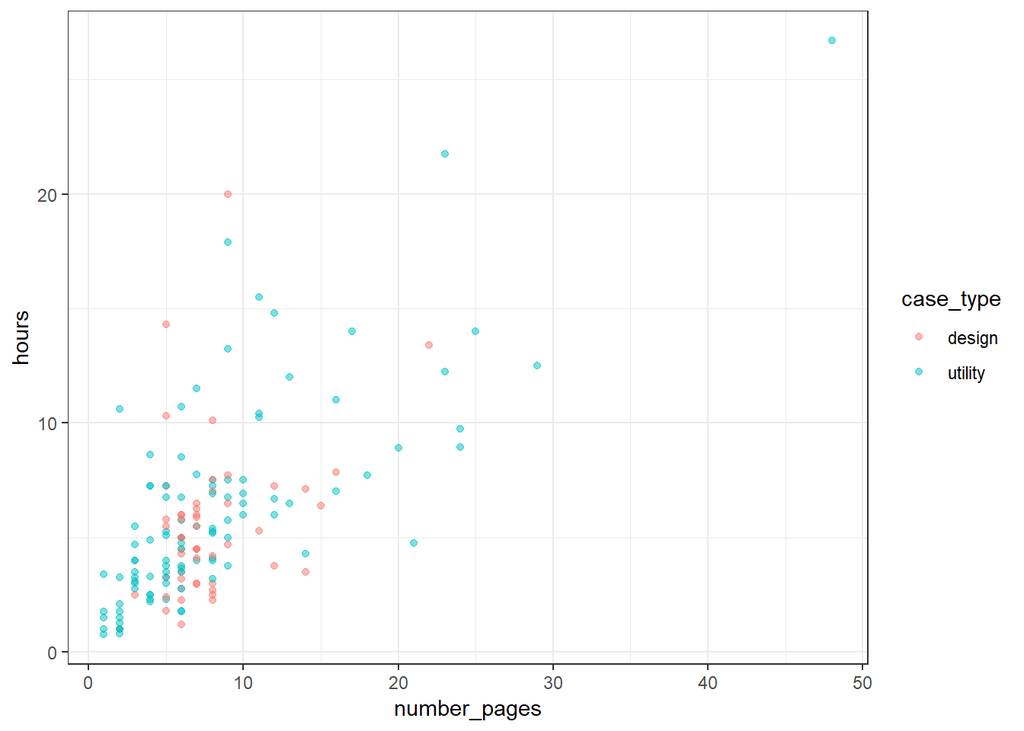

```r
ggplot(df, aes(x=number_pages, y=hours)) +
  geom_point(aes(color=case_type),alpha=0.5) +
  theme_bw()
```

Here we can see what looks like a linear relationship between **hours** and **number_pages**. There is more variance, however, when we get an increase in page counts. As mentioned in previous explorations of this data, this is due to the fact that some projects have quite a bit more complexity than others. For this reason, I need a way to assign a difficulty rating to a project I’m estimating so that I can narrow the range of possible variance for the predicted hours variable.

Let’s now take a look at the same plot, but colored by difficulty instead of case type.

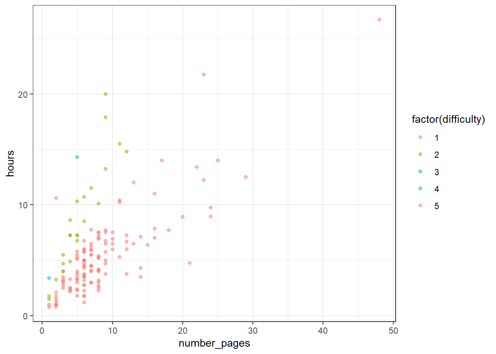

```r
ggplot(df, aes(x=number_pages, y=hours)) +
  geom_point(aes(color=factor(difficulty)),alpha=0.5) +
  theme_bw()
```

This highlights the problem I mentioned earlier about how we aren’t really making full use of the engineered **difficulty** variable. We can see the single instances of the projects with the 3, 4, and 5 difficulty levels.

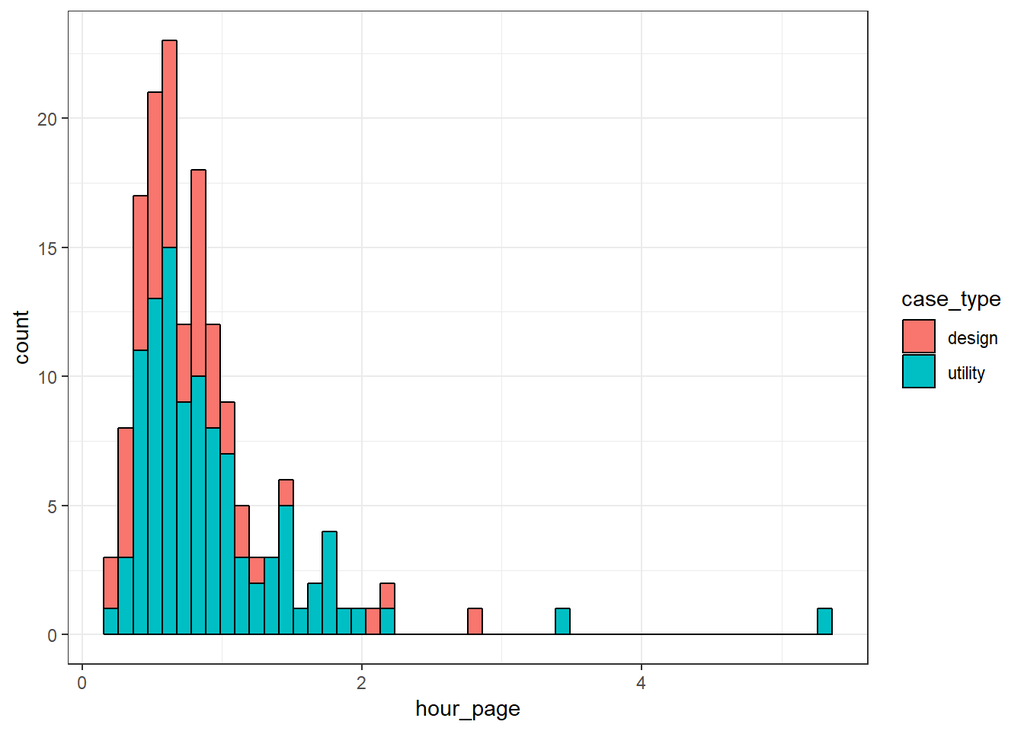

```r
ggplot(df, aes(hour_page)) +
  geom_histogram(aes(fill=case_type), color='black', bins = 50) +
  theme_bw()
```

Let’s smooth this out by looking at a density plot.

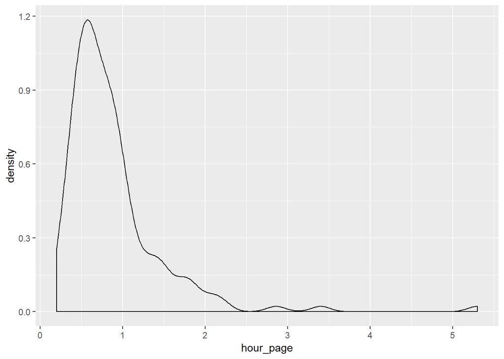

```r
ggplot(df, aes(hour_page)) +
  geom_density()
```

Here we can see good evidence that it doesn’t make sense to break up the difficulty variable *evenly*.

This visualization reflects what I see see day-to-day in my business: the majority of the projects are similar enough in that they take roughly the same amount of time – per page – to complete. These would be my *normal* projects. I would like a difficulty level below *normal* however, in order to catch those projects that are more simple and take quite a bit less time per page. Then it’s nice to have a few difficulty levels above the norm for those less-common, more complex projects.

This graph shows that the *vast* majority of cases take between 0.2 and about 1.25 hours per page. The rest are pretty rare, so I can divide up my level of difficulty cutoffs to reflect this. Let’s visually show where I might make these divisions based on the above graphs.

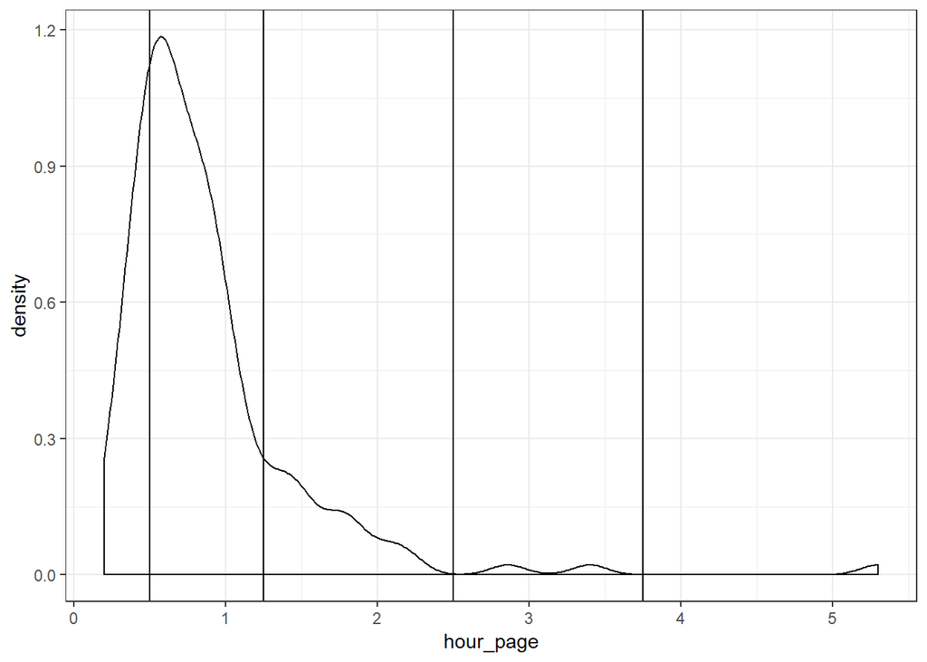

```r
ggplot(df, aes(hour_page)) +
  geom_density() +
  geom_vline(xintercept = 0.5) +
  geom_vline(xintercept = 1.25) +
  geom_vline(xintercept = 2.5) +
  geom_vline(xintercept = 3.75) +
  theme_bw()
```

Let’s create a function to divide the **hour_page** variable based on these new insights.

```r
create_difficulty <- function(x){
  if (x < 0.5){
    return(1)
  } else if (x >= 0.5 & x < 1.25){
    return(2)
  } else if (x >= 1.25 & x < 2.5){
    return(3)
  } else if (x >= 2.5 & x < 3.75){
    return(4)
  } else{
    return(5)
  }
}
```

Next, we’ll apply the function to the **hour_page** column. We can simply over-write the existing **difficulty** column since those old values are no longer desired.

```r
df$difficulty <- sapply(df$hour_page, create_difficulty)
```

```r
head(df)
```

```
##   case_type number_pages X3d_modeling hours hour_page difficulty
## 1    design            6           no  2.75 0.4583333          1
## 2   utility           16           no 11.00 0.6875000          2
## 3   utility            5           no  3.75 0.7500000          2
## 4   utility            9           no  5.75 0.6388889          2
## 5   utility            4           no  7.25 1.8125000          3
## 6   utility           23           no 12.25 0.5326087          2
```

Let’s take another look at the scatter plot from above with these new divisions.

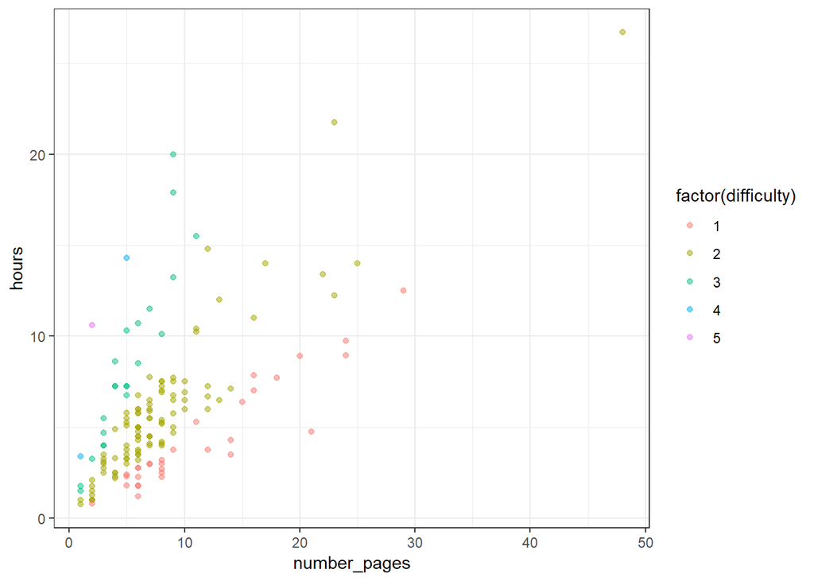

```r
ggplot(df, aes(x=number_pages, y=hours)) +
  geom_point(aes(color=factor(difficulty)),alpha=0.5) +
  theme_bw()
```

In the above graph we can easily see that we are utilizing all the difficulty levels. Let’s now look at the difficulty levels individually as they relate to hours.

Let’s look at the projects with a difficulty of 1.

```r
level.one <- df %>% filter(difficulty == 1)
```

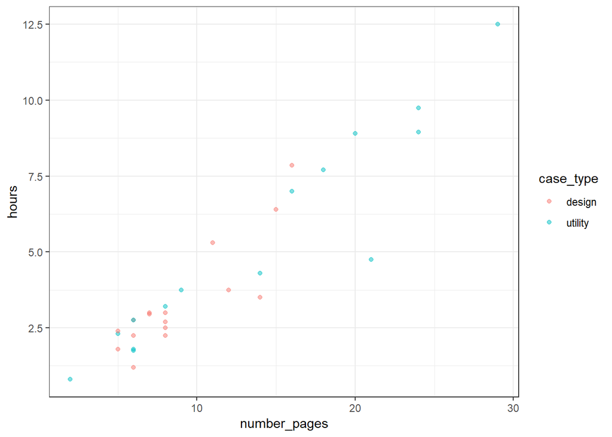

```r
ggplot(level.one, aes(x=number_pages, y=hours)) +
  geom_point(aes(color=case_type),alpha=0.5) +
  theme_bw()
```

Projects with a difficulty of 2:

```r
level.two <- df %>% filter(difficulty == 2)
```

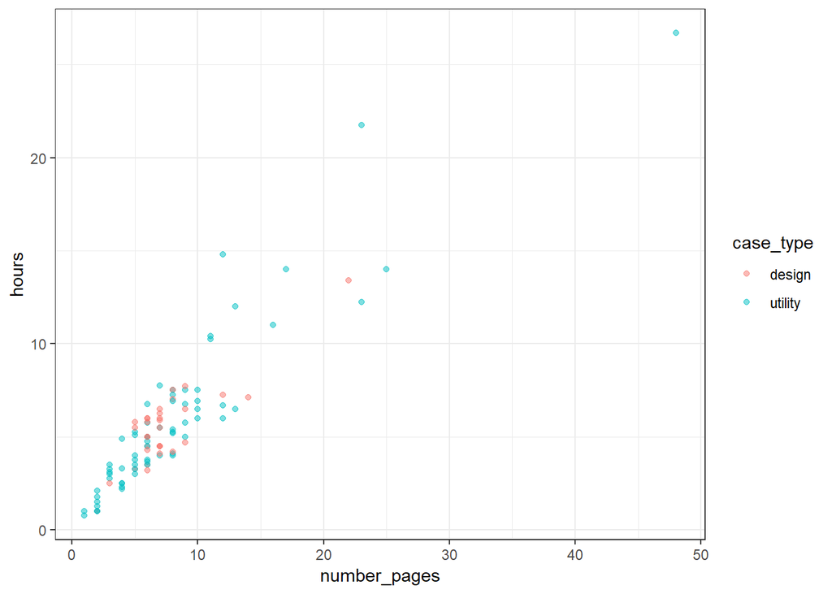

```r
ggplot(level.two, aes(x=number_pages, y=hours)) +
  geom_point(aes(color=case_type),alpha=0.5) +
  theme_bw()
```

Level 3:

```r
level.three <- df %>% filter(difficulty == 3)
```

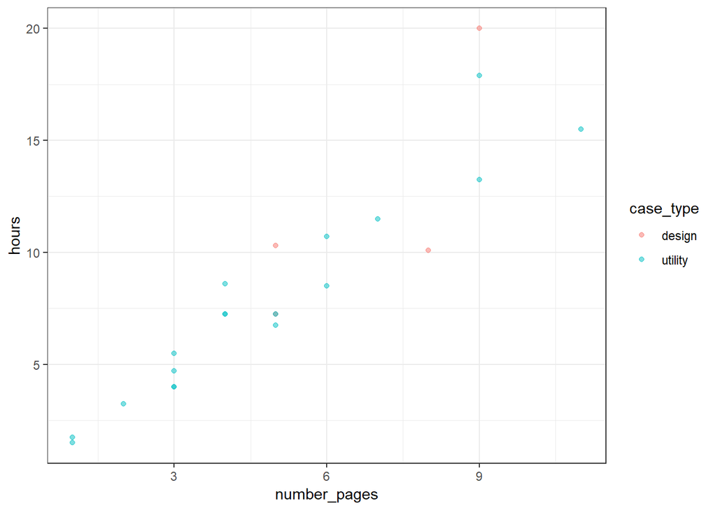

```r
ggplot(level.three, aes(x=number_pages, y=hours)) +
  geom_point(aes(color=case_type),alpha=0.5) +
  theme_bw()
```

We also see that it’s pretty rare to have a **design** project in this difficulty level. With the above visuals, there appears to be an even stronger linear relationship between each difficulty level’s hours and number of pages.

Let’s move on to creating our Linear Regression model.

## Building the Model

We’ll select only the features we want to model. We don’t need the **hour_page** column, as it was used only to make the **difficulty** column.

```r
final_df <- df %>% select(case_type, number_pages, X3d_modeling, difficulty, hours)
```

### Train Test Split

```r
library(caTools)

#Split the sample

sample <- sample.split(final_df$hours, SplitRatio = 0.7)

#Training Data
train = subset(final_df, sample=TRUE)

#Test Data
test = subset(final_df, sample=FALSE)
```

### Train the Model

```r
model <- lm(hours ~ ., train)
```

```r
summary(model)
```

```
##
## Call:
## lm(formula = hours ~ ., data = train)
##
## Residuals:
##     Min      1Q  Median      3Q     Max
## -5.4123 -1.1373 -0.1290  0.7834  9.2622
##
## Coefficients:
##                  Estimate Std. Error t value Pr(>|t|)
## (Intercept)      -5.70182    0.65642  -8.686 5.93e-15 ***
## case_typeutility -0.31556    0.40680  -0.776    0.439
## number_pages      0.57798    0.02843  20.332  < 2e-16 ***
## X3d_modelingyes   0.54905    0.47532   1.155    0.250
## difficulty        3.56292    0.27158  13.119  < 2e-16 ***
## ---
## Signif. codes:  0 '***' 0.001 '**' 0.01 '*' 0.05 '.' 0.1 ' ' 1
##
## Residual standard error: 2.04 on 150 degrees of freedom
## Multiple R-squared:  0.7609, Adjusted R-squared:  0.7546
## F-statistic: 119.4 on 4 and 150 DF,  p-value: < 2.2e-16
```

## Stepwise Algorithm

```r
new.step.model <- step(model)
```

```
## Start:  AIC=225.99
## hours ~ case_type + number_pages + X3d_modeling + difficulty
##
##                Df Sum of Sq     RSS    AIC
## - case_type     1      2.51  626.98 224.61
## - X3d_modeling  1      5.55  630.03 225.36
## <none>                       624.47 225.99
## - difficulty    1    716.53 1341.01 342.45
## - number_pages  1   1720.95 2345.43 429.10
##
## Step:  AIC=224.61
## hours ~ number_pages + X3d_modeling + difficulty
##
##                Df Sum of Sq     RSS    AIC
## <none>                       626.98 224.61
## - X3d_modeling  1     13.03  640.01 225.80
## - difficulty    1    759.45 1386.43 345.61
## - number_pages  1   1727.29 2354.27 427.69
```

```r
summary(new.step.model)
```

```
##
## Call:
## lm(formula = hours ~ number_pages + X3d_modeling + difficulty,
##     data = train)
##
## Residuals:
##     Min      1Q  Median      3Q     Max
## -5.3738 -1.1397 -0.2008  0.8840  9.3903
##
## Coefficients:
##                 Estimate Std. Error t value Pr(>|t|)
## (Intercept)     -5.80120    0.64294  -9.023 7.85e-16 ***
## number_pages     0.57557    0.02822  20.396  < 2e-16 ***
## X3d_modelingyes  0.73122    0.41271   1.772   0.0785 .
## difficulty       3.49985    0.25878  13.524  < 2e-16 ***
## ---
## Signif. codes:  0 '***' 0.001 '**' 0.01 '*' 0.05 '.' 0.1 ' ' 1
##
## Residual standard error: 2.038 on 151 degrees of freedom
## Multiple R-squared:   0.76,  Adjusted R-squared:  0.7552
## F-statistic: 159.4 on 3 and 151 DF,  p-value: < 2.2e-16
```

## Predictions

```r
hours.predictions <- predict(new.step.model, test)
```

```r
results <- cbind(hours.predictions, test$hours)
colnames(results) <- c("pred", "real")
results <- as.data.frame(results)
```

Taking care of negative predictions.

```r
to_zero <- function(x){
  if(x < 0){
    return(0)
  } else{
    return(x)
  }
}
```

```r
results$pred <- sapply(results$pred, to_zero)
```

### Mean Squared Error

```r
mse <- mean((results$real - results$pred)^2)
print(mse)
```

```
## [1] 4.024624
```

With the above MSE I now have a baseline to measure against future linear regression models.

## Conclusion

The above EDA was very productive in that I was able to assign **difficulty** value that was more representative of the distribution of the data.

The Linear Regression model was not very strong, but it does serve to give me a starting point when making an estimation. I’ve tested it out on a few recent projects, and I was pleased with the level of accuracy.

But as always, I will continue to collect more data as time goes on. I look forward to finding better models to serve as a project-length predictor. Thanks for checking this out!